# CAIXA Report

Wind Resource Assessment

Author

by Francisco Costa

Published

June 16, 2026

Abstract

This report presents a mini wind resource assessment for the CAIXA wind farm, a hypothetical 9-turbine coastal wind project located on the western coast of Denmark. Meteorological observations from the Høvsøre reference mast are used to characterise the wind climate, while terrain elevation and surface roughness data are employed to model spatial variations in wind conditions across the site. The study includes data quality control, wind climate characterisation, terrain and flow modelling, wake loss estimation, annual energy production (AEP) calculations, and uncertainty analysis. The report provides an integrated overview of the site’s wind enery potential.

# 1 Executive summary

The CAIXA 9-turbine coastal wind farm is estimated to achieve a net annual energy production (AEP) of **121.98 GWh/yr** at P50 exceedance level. The bankable P90 lies at **109.70 GWh/yr**, a gap of 10.1 % below P50, driven by a combined relative uncertainty of σ = **7.9**%. The assessment uses the PARK2 wake model at an air density of 1.230 kg/m³.

Table 1: Headline P-value summary (farm total).

| P-value | AEP [GWh/yr] | Δ vs P50 |
| --- | --- | --- |
| P50 | 121.98 | — |
| P75 | 115.52 | 5.30 % |
| P90 | 109.7 | 10.07 % |

# 2 Project description

The site comprises **9 turbines** of model VESTAS 3.0MW V112, 84 m hub height, distributed in three rows of three turbines each along the North Sea coast line in western Denmark. The layout is shown in Figure 1.

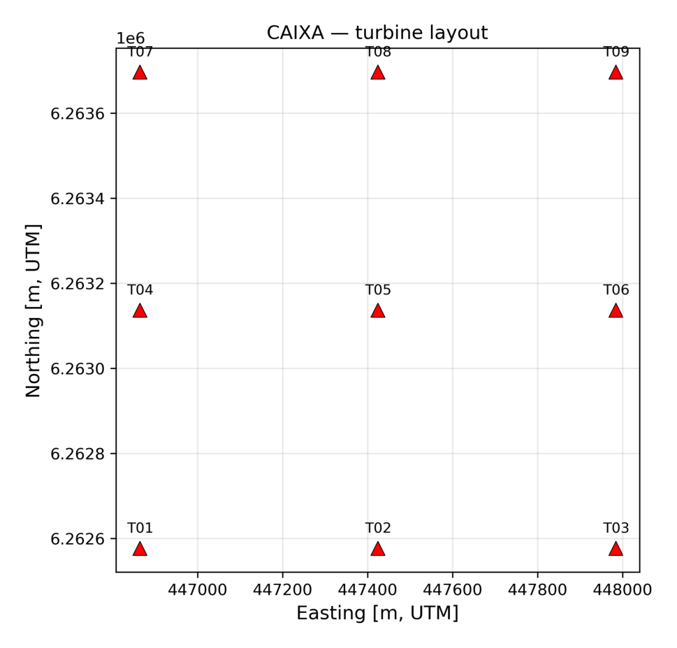

Figure 1: CAIXA 9 layout (UTM32N coordinates).

# 3 Mast data and Quality Control (QC)

The assessment is based on measurements acquired at the Høvsøre meteorological mast, located at approximately 447.64 km Easting and 6255.43 km Northing EPSG:25832 UTM32N. The measurement campaign spans the period from 2013-01-01 00:06:00 to 2014-12-31 23:56:00, corresponding to a total monitoring period of 1.996 years.

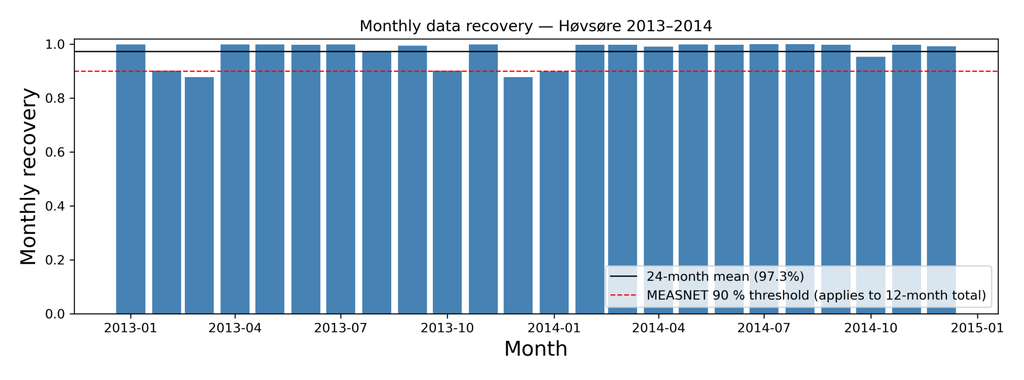

Figure 2: Monthly data recovery before boom switching.

Wind observations at 80 m above ground level(AGL) are selected as reference dataset for the resource assessment due to their superior data availability and representativeness of the target hub height. To maximise data recovery and minimise mast-induced flow distortion, a boom-switching procedure is applied. Wind direction measurements are derived from the 60 m wind vane, while wind speed measurements at 80 m AGL are obtained from a combined dataset comprising cup and sonic anemometer observations. Monthly recovery data before boom switching is shown in Figure 2. QC and boom-switching results in an overall data coverage of 98.13%.

# 4 Site & terrain description

The RUNE reference location is situated on the western coast of Denmark within a predominantly agricultural landscape adjacent to the North Sea coastline. The site is located near a pronounced coastal escarpment that introduces measurable orographic acceleration effects under selected wind directions.

The dominant terrain-induced flow modification is associated with coastal escarpment speed-up effects, whereas overall terrain complexity remains low (RIX ~ 0.003) at CAIXA area, indicating a relatively simple topographic setting with minimal flow distortions. Elevation, roughness, mast and wind farm locations are shown in Figure 3.

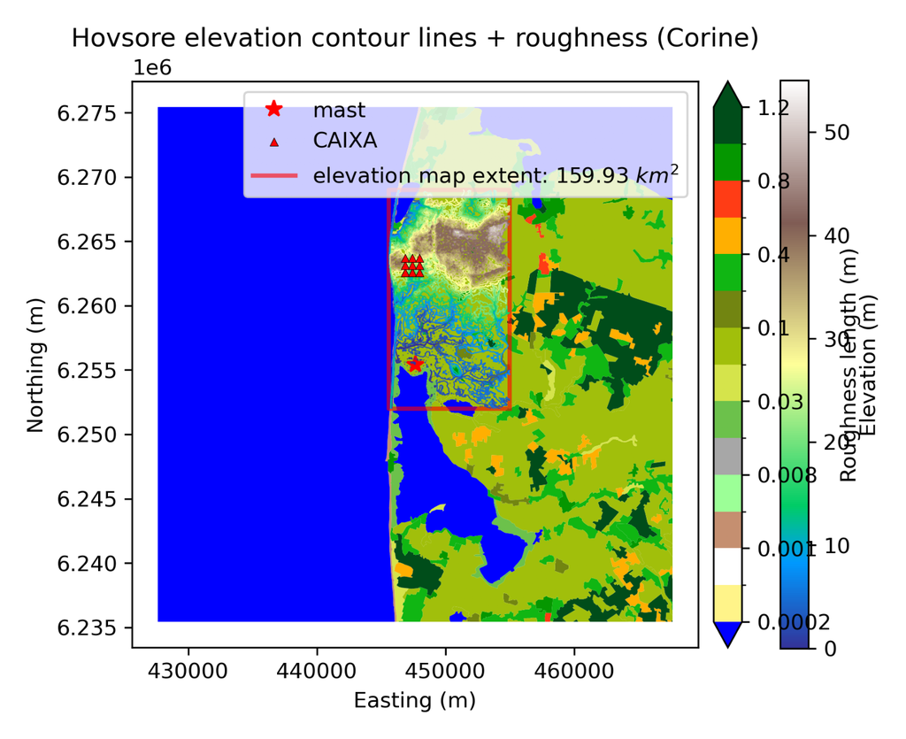

Figure 3: Elevation, roughness and mast and wind farm location.

# 5 Measurement & wind climate

A single meteorological mast equiped with sonic and cup anemometeres at 60, 80, 100 and 116 m and vanes at 10, 60 and 100 m recorded wind speed and direction through a two-year campaign meeting MEASNET v3.1 (2022) minimum recovery thresholds (2013: 96.1%, 2014: 98.6%, with overall recovery (24 months) : 97.3%). The hub-height wind rose at CAIXA wind farm is shown in Figure 4.

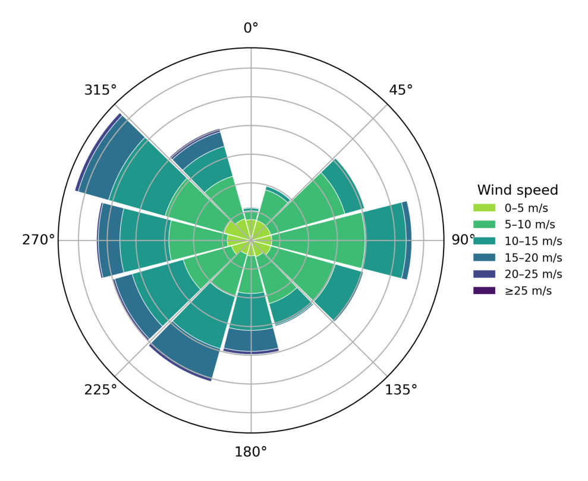

Figure 4: Wind rose at hub-height (CAIXA).

# 6 Resource map at CAIXA

The resource grid consists of a 200 m spatial resolution domain centered on RUNE, extended by a 5 km buffer, and subsequently clipped to the spatial extent of the available elevation dataset. Mean wind speed and power density resource maps are shown in Figure 5.

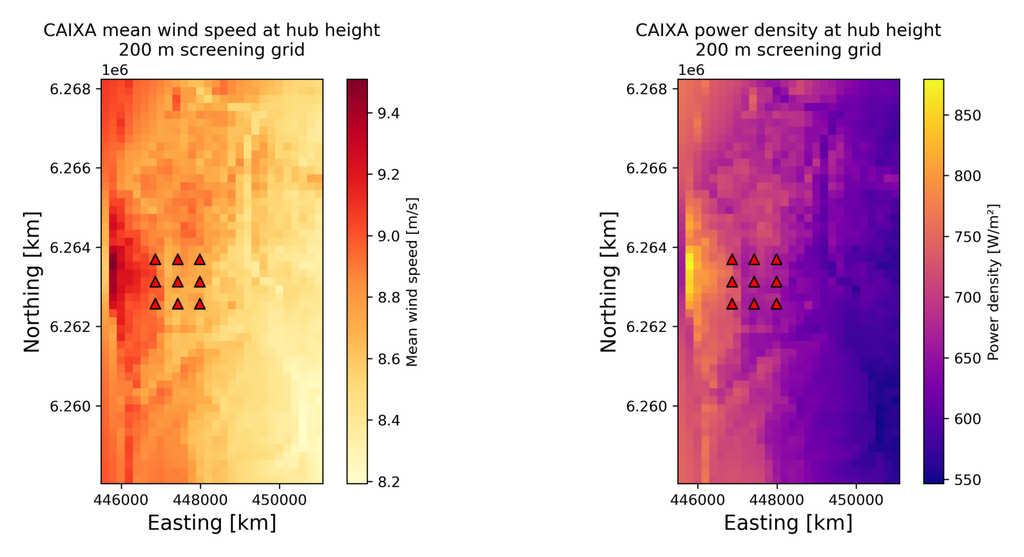

Figure 5: Wind velocty and power density resource grids at RUNE.

# 7 Methodology

After QC, Høvsøre binned wind climate (bwc) is derived from 80 m height mast records. Weibull wind climate is derived and used to predict climate at CAIXA wind farm. The generalised wind climate was applied to the 9 turbine positions through the WAsP linearised flow model (`pywasp.wasp.predict_wwc`, vNA) and mesoclimate corrections, producing a per-turbine, per-sector wind climate. The PARK2 wake model (`pywake.deficit_models`, vNA) combined the climate with the turbine power curve at an air density of 1.230 kg/m³ to produce gross and potential AEP per turbine per sector. Operational losses were applied as a multiplicative retention factor; uncertainty was projected to P50/P75/P90 assuming normally distributed uncertainty with combined relative standard deviation of σ = 7.86 %.

# 8 Gross, potential, and net AEP

Table 2: Operational loss table. DTU default.

| loss_name | loss_percentage | loss_category |
| --- | --- | --- |
| turbine_availability | 1 | Availability |
| balance_plant_availability | 0 | Availability |
| grid_availability | 0.5 | Availability |
| electrical_operation | 0.5 | Electrical |
| wf_consumption | 0.2 | Electrical |
| sub_optimal_performance | 0 | Turbine_performance |
| power_curve | 1 | Turbine_performance |
| hysteresis | 0 | Turbine_performance |
| icing | 0 | Environmental |
| blade_degradation | 0.25 | Environmental |
| other_environmental_losses | 0.1 | Environmental |
| exposure_changes | 0 | Environmental |
| load_grid_curtailments | 0.5 | Curtailments |
| noise_visual_curtailments | 0 | Curtailments |
| sector_management | 0.5 | Operational_strategies |

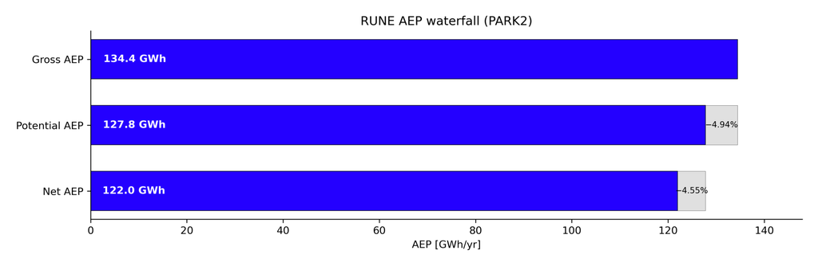

Figure 6: AEP waterfall: gross → potential → net.

The largest deduction in the chain corresponds to PARK2 wake modelling, followed by data availability and turbine performance losses.

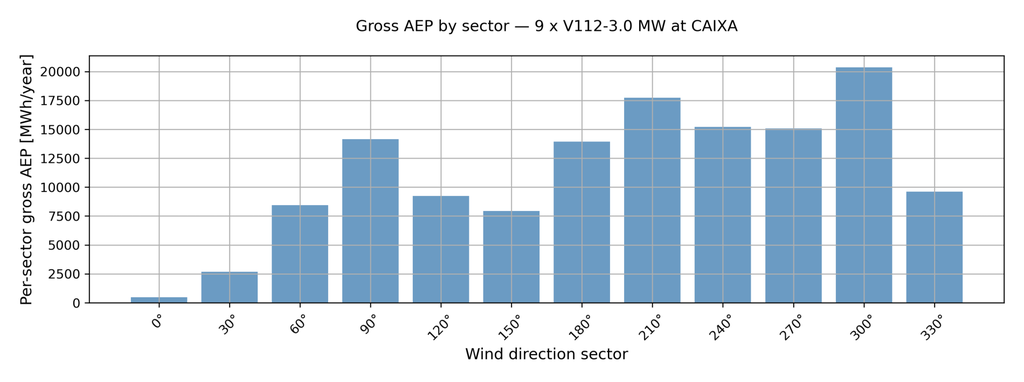

Yearly per-sector AEP at CAIXA.

# 9 Uncertainty assessment

Combining the wind-kind and energy-kind contributions in quadrature yields a single relative σ = 7.9 %.

Table 3: Uncertainty table. DTU default.

| uncertainty_kind | uncertainty_name | uncertainty_percentage |
| --- | --- | --- |
| wind | representativeness_long_term_period | 2 |
| wind | reference_data_consistency | 0.5 |
| wind | long_term_adjustment_mcp | 1.5 |
| wind | ws_distribution_uncertainty | 0.5 |
| wind | on_site_data_synthesis | 0.2 |
| wind | measurements_representativeness | 0.1 |
| wind | iav_variability | 0.21 |
| wind | ws_measurements_uncertainty | 2 |
| wind | wd_measurements_uncertainty | 1 |
| wind | other_atm_param_uncertainty | 0.5 |
| wind | data_integrity | 0.5 |
| wind | he_model_inputs | 1.08 |
| wind | he_model_sensitivity | 2.64 |
| wind | he_model_appropriateness | 2.17 |
| wind | ve_model_uncertainty | 0.8 |
| wind | ve_propagated_measurement_uncertainty | 0.73 |
| energy | turbine_interaction_wake_blockage_effects | 1.76 |
| energy | turbine | 2.5 |
| energy | balance_of_plant | 1.17 |
| energy | grid | 0.5 |
| energy | electrical_efficiency | 0.5 |
| energy | parasitic_consumption | 0 |
| energy | sub_optimal_performance | 0.71 |
| energy | generic_power_curve_adjustments | 2 |
| energy | site_specific_power_curve_adjustments | 0.87 |
| energy | high_wind_hysteresis | 0 |
| energy | icing | 0.01 |
| energy | degradation | 0.25 |
| energy | environmental_loss_uncertainty | 0.01 |
| energy | exposure_changes | 0 |
| energy | load_curtailment | 0.01 |
| energy | grid_curtailment | 0 |
| energy | environmental_curtailment | 0.01 |
| energy | operational_strategies | 0.01 |

Under a Gaussian assumption applied multiplicatively to net AEP, P50 lands on the net value (121.98 GWh), with P75 and P90 sitting 5.30 % and 10.07 % below. Built-in `pywasp.estimate_sensitivity_factor` estimates a sensitivity factor of sf = 1.31. Table 3 ilustrates uncertainty kind and considered uncertainty percentage. Figure 7 shows the spread.

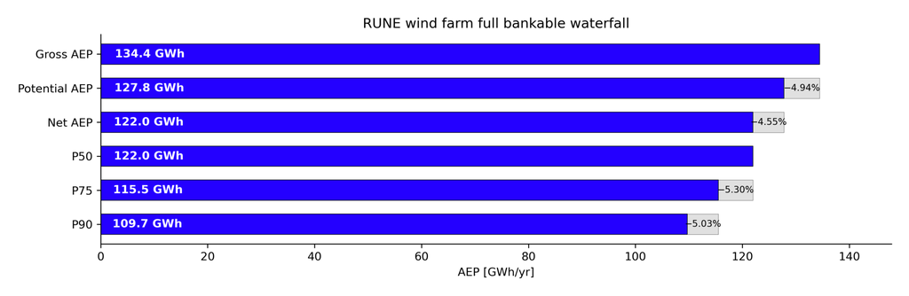

Figure 7: Farm-total P50, P75, P90 exceedance AEP.

The bankable headline for project finance is the **P90**: lenders size debt against a value the project is expected to exceed in 90 % of years.

# 10 Methodology appendix

## 10.1 Software versions

Table 4: Software versions used for this assessment.

| package | version |
| --- | --- |
| python | 3.13.13 |
| windkit | 2.1.0 |
| pywasp | 2.0.0 |
| pywake | 2.6.12 |
| quarto | (not available) |

## 10.2 Git revision and pixi lockfile

- **Git SHA:** `ee9ac02`

- **Pixi lockfile SHA-256[:12]:** `91c14e266d87`

## 10.3 Input assumptions

Table 5: Input parameters and assumptions.

| Parameter | Value |
| --- | --- |
| Turbine model | V112 |
| Number of turbines | 9 |
| Hub height [m] | 84 |
| Air density [kg/m³] | 1.230 |
| Ambient TI | 0.12 |
| Wake model | park2_onshore |
| Loss table | DTU-default |
| Uncertainty σ (relative) | 7.9 % |
| Git SHA | ee9ac02 |
| Pixi lockfile SHA-256[:12] | 91c14e266d87 |

# 11 References

- IEC 61400-15-1:2025 — Site suitability input conditions for wind power plants.
- IEC 61400-15-2 (draft) — Energy yield assessment; includes the EYA DEF JSON exchange format.
- MEASNET v3.1 (2022) — Evaluation of Site-Specific Wind Conditions.